# SLE IFN clinical trials - data preparation

Our SLE WB compendium includes [a trial of interferon-alpha-kinoid (IFN-K)](https://doi.org/10.1002/art.37785), which should block type I IFN only and therefore the expression levels of IFN-alpha/IFN-beta gene signatures should decrease during treatment (leaving IFN-gamma signature expression relatively unchanged). [A trial of AMG-811](https://www.ncbi.nlm.nih.gov/pmc/articles/PMC5054935/), which is a monoclonal antibody against IFN-gamma, is also included. We expected to see IFN-gamma gene expression decrease in the AMG-811 during treatment.

In this notebook, we’ll tidy data in preparation for analyzing changes in IFN-related gene expression using a couple different gene sets or models – modular transcriptional analyses (from [Chiche, et al. 2014.](https://www.ncbi.nlm.nih.gov/pmc/articles/PMC4157826/)), a PLIER model trained on the SLE WB compendium and a PLIER model trained on recount2 data.

For more information about the types of IFNs, see the intro to `08-identify_ifn_LVs`.

## Functions and directory set up

```r
`%>%` <- dplyr::`%>%`
```

#### Functions specifically for modular analyses

```r
ReadInTribeConversions <- function(filename) {
  # Reads in csv file downloaded from Tribe and returns character vector.
  # The gene identifiers start at the 7th line.
  #
  # Args:
  #   filename: full path to csv file containing the list of gene identifers
  #
  # Returns:
  #   geneset: a vector (character) of gene identifiers
  #

  geneset <- readLines(filename)
  geneset <- geneset[7:length(geneset)]
  geneset <- gsub("\t", "", geneset)
  return(geneset)
}
GetGeneSetMean <- function(gene.set, exprs) {
  # Summarize the expression levels of genes in a gene set by taking the mean
  # expression value of all genes in that gene set
  #
  # Args:
  #   gene.set: vector of gene identifiers -- corresponds to the geneset to be
  #             summarized
  #   exprs: data.frame that contains the expression values (rows are genes,
  #          columns are samples); first column -- "Gene" -- contains gene ids
  #          (match the type of identifiers used in gene.set)
  #
  # Returns:
  #   summary.df: a data.frame, 1 row corresponding to the mean expression
  #               values for genes in gene.set, columns are samples
  #

  if (colnames(exprs)[1] != "Gene") {
    stop("The first column must contain gene identifiers and have
         the colname 'Gene'")
  }

  `%>%` <- dplyr::`%>%`
  summary.df <- exprs %>%
                  dplyr::filter(Gene %in% gene.set) %>%
                  dplyr::select(-Gene) %>%
                  dplyr::summarise_all(mean)

  return(summary.df)

}
```

```r
# plot and result directory setup for this notebook
plot.dir <- file.path("plots", "09")
dir.create(plot.dir, recursive = TRUE, showWarnings = FALSE)
results.dir <- file.path("results", "09")
dir.create(results.dir, recursive = TRUE, showWarnings = FALSE)
```

```r
# set seed for reproducibility (plot jitter)
set.seed(123)
```

## IFN-K

**E-GEOD-39088; Lauwerys, et al. 2013.**

First, I’ll summarize some relevant points from Lauwerys, et al.:

- IFN-K is a therapeutic vaccine. It induces IFN-alpha antibodies in those who receive it. In turn, those antibodies will bind IFN-alpha and therefore reduce its activity/ability to stimulate the immune system.
- Patients with SLE were treated with one of four doses of IFN-K or placebo.
- Whole blood was collected from patients at days 0 (baseline), 112, and 168.
- Healthy control blood was also included (2 samples from each control); one of these healthy control blood samples was treated with type I IFNs (IFN-alpha subtype(s) specifically) to derive an IFN-inducible gene expression signature.
- The authors stratified patients into *IFN-positive* (n = 18) and *IFN-negative* (n = 9) groups based on the expression levels of the IFN-inducible gene signature at baseline.
- Patients with a IFN-positive baseline signature had a reduction in IFN-inducible treatment during treatment.

We do not have information about which patients are in which of these two groups, so we’ll have to designate IFN-positive and IFN-negative samples based on our own results.

### Modular transcriptional analyses

Module gene set information was obtained from [the associated public wiki](https://www.biir.net/public_wikis/module_annotation/V2_Trial_8_Modules) and converted to Entrez IDs with [Tribe](http://tribe.greenelab.com/). The resulting gene sets are in `data/module_genesets`.

In Chiche, et al., it was demonstrated that `M1.2`, `M3.4`, and `M5.12` are all associated with IFN. More specifically, `M1.2` captures mostly type I IFN-inducible gene expression, whereas the other two modules are likely induced by type II IFN (though type I IFN-inducible may be captured as well).

#### Read in SLE WB data (Entrez IDs)

```r
exprs.file <- file.path("data", "expression_data",
                        "SLE_WB_all_microarray_QN_zto_before.pcl")
exprs.df <- data.table::fread(exprs.file, data.table = FALSE)
```

```
Read 63.2% of 15827 rows
Read 15827 rows and 1641 (of 1641) columns from 0.418 GB file in 00:00:06
```

#### Summarize modules’ gene expression

All SLE data

```r
# read in Tribe-converted genesets
mod.file.list <-
  list(M1.2 = file.path("data", "module_genesets",
                        "Chiche et al M1.2 module-6b45452.csv"),
       M3.4 = file.path("data", "module_genesets",
                        "Chiche et al M3.4 module-7ab0d0d.csv"),
       M5.12 = file.path("data", "module_genesets",
                         "Chiche et al M5.12 module-f326fe4.csv"))
entrez.mod.list <- lapply(mod.file.list,
                          function(x) ReadInTribeConversions(x))
```

```r
# get expression summary (mean)
mod.summary.list <-
  lapply(entrez.mod.list, function(x) GetGeneSetMean(x, exprs.df))
# tidy
mod.summary.df <- reshape2::melt(mod.summary.list)
colnames(mod.summary.df) <- c("Source Name", "Summary", "Module")
# write to file
readr::write_tsv(x = mod.summary.df,
                 path = file.path(results.dir,
                                  "SLE-WB_Chiche_et_al_module_summary.tsv"))
```

#### Sample-data relationship

```r
e.39088.sdrf <- data.table::fread(file.path("data",
                                            "sample_info",
                                            "E-GEOD-39088.sdrf.txt"),
                                  data.table = FALSE)
array.att <- e.39088.sdrf[, c("Source Name",
                              "Comment [Sample_characteristics]",
                              "Characteristics [disease state]",
                              "Comment [Sample_source_name]",
                              "Comment [Sample_title]")]
# source name must match exprs.df colnames (CEL file names) in order to
# join df
array.att <-
  array.att %>%
    dplyr::mutate(`Source Name` =  gsub(" 1", "", `Source Name`))
array.att$`Source Name` <-
  unlist(lapply(array.att$`Source Name`,
         function(x) colnames(exprs.df)[grep(x, colnames(exprs.df))]))
colnames(array.att)[2:ncol(array.att)] <- c("Day", "Disease state",
                                            "Treatment", "Patient")
```

#### Main

```r
# right join, only want arrays in this data set
mod.meta.df <-
  dplyr::right_join(mod.summary.df, array.att, by = "Source Name")
```

```
Column `Source Name` joining factor and character vector, coercing into character vector
```

```r
# baseline and healthy unstimulated only
baseline.mod.df <-
  dplyr::bind_rows(dplyr::filter(mod.meta.df, Day == "day: 0"),
                   dplyr::filter(mod.meta.df,
                                 `Disease state` == "healthy" & !(grepl("unstimulated",
                                                                        Treatment))))
rm(mod.meta.df)
```

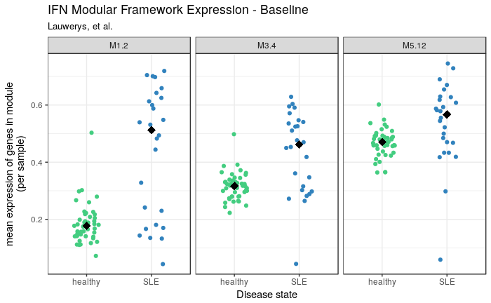

```r
p <- ggplot2::ggplot(baseline.mod.df,
       ggplot2::aes(x = `Disease state`, y = Summary)) +
  ggplot2::geom_jitter(ggplot2::aes(colour = `Disease state`), width = 0.2) +
  ggplot2::stat_summary(fun.y = "median", size = 4, shape = 18,
                        geom = "point", color = "black") +
  ggplot2::facet_grid(~ Module) +
  ggplot2::theme_bw() +
  ggplot2::labs(y = "mean expression of genes in module\n(per sample)",
                title = "IFN Modular Framework Expression - Baseline",
                subtitle = "Lauwerys, et al.") +
  ggplot2::scale_color_manual(values = c("seagreen3", "#3182bd")) +
  ggplot2::theme(legend.position = "none")
p
```

```r
# save plot
plot.file <- file.path(plot.dir,
                       "E-GEOD-39088_Chiche_et_al_baseline.pdf")
ggplot2::ggsave(plot.file, plot = p +
                  ggplot2::theme(text = ggplot2::element_text(size = 15)))
```

```r
# which are likely the 9 IFN-negative patients in the original publication
# we don't have these labels
low.ifn.sle <- dplyr::filter(baseline.mod.df,
                             `Disease state` == "SLE") %>%
  dplyr::group_by(Module) %>%
  dplyr::top_n((Summary * -1), n = 9)
# call low samples 9 lowest M1.2 scores -- TYPE I INTERFERON
low.ifn.samples <-low.ifn.sle$`Source Name`[low.ifn.sle$Module == "M1.2"]
low.ifn.samples
```

```
[1] "GSM955819_DNA11091-067.CEL" "GSM955807_DNA11091-061.CEL" "GSM955804_DNA10204-307.CEL"
[4] "GSM955786_DNA10204-285.CEL" "GSM955783_DNA10204-281.CEL" "GSM955774_DNA10204-333.CEL"
[7] "GSM955771_DNA10204-337.CEL" "GSM955762_DNA10204-341.CEL" "GSM955759_DNA10204-309.CEL"
```

```r
# remove low ifn samples that are placebo, that will be its own category
low.ifn.samples <-
  low.ifn.samples[!grepl("Placebo",
                         array.att$`Treatment`
                         [array.att$`Source Name` %in% low.ifn.samples])]
# get the treatment day (or timepoint information) from treatment column
# and get the patient identifier from patient column
array.att <-
  array.att %>%
    dplyr::mutate(Day = sub("^\\s+", "", sub(".*[,]", "", Treatment)),
                  Patient = sub("^\\s+", "", sub(".*[,]", "", Patient)))
# healthy controls do not have timepoint information, so replace with NA
array.att$Day[!grepl(paste(c("day", "baseline"), collapse = "|"),
                            array.att$Day)] <- NA
# add a column that contains grouping information (IFN-K treated, placebo
# unstimulated control, stimulated control)
array.att <-
  array.att %>%
    dplyr::mutate(Group =
                    dplyr::case_when(
                      grepl("IFN-K", array.att$Treatment) ~ "IFN-K",
                      grepl("Placebo", array.att$Treatment) ~ "Placebo",
                      grepl("absence", array.att$Treatment) ~
                        "Control, no treatment",
                      grepl("unstimulated = ", array.att$Treatment) ~
                        "Control, stimulated"
                    ))
# which patients are in the following groups - placebo, IFN-positive,
# IFN-negative
low.ifn.pat <-
  array.att$Patient[which(array.att$`Source Name` %in% low.ifn.samples)]
placebo.pat <- unique(array.att$Patient[which(array.att$Group == "Placebo")])
hi.ifn.pat <- setdiff(array.att$Patient, c(low.ifn.pat, placebo.pat))
hi.ifn.pat <- hi.ifn.pat[grep("patient", hi.ifn.pat)]
array.att <-
  array.att %>%
    dplyr::mutate(`IFN-level` = rep(NA, nrow(array.att))) %>%
    dplyr::mutate(`IFN-level` = dplyr::case_when(
      (Patient %in% low.ifn.pat) ~ "IFN-negative",
      (Patient %in% placebo.pat) ~ "Placebo",
      (Patient %in% hi.ifn.pat) ~ "IFN-positive"
    ))
# right join, only want arrays in this data set
mod.meta.df <-
  dplyr::right_join(mod.summary.df, array.att, by = "Source Name")
```

```
Column `Source Name` joining factor and character vector, coercing into character vector
```

```r
# write to file
readr::write_tsv(mod.meta.df,
                 path = file.path(results.dir,
                                  "E-GEOD-39088_Chiche_et_al_module.tsv"))
```

```r
rm(list = setdiff(ls(), c("%>%", "mod.summary.df", "array.att",
                          "results.dir", "plot.dir")))
array.att <- dplyr::select(array.att, -`IFN-level`)
```

### PLIER trained on SLE WB compendium

```r
sle.b.df <- readr::read_tsv(file.path("results", "05",
                                      "SLE-WB_PLIER_B_tidy.tsv"))
```

Need to find which samples would be considered IFN-positive vs. IFN-negative using this information

```r
ifn.b.df <- sle.b.df %>%
              dplyr::filter(LV %in% c("LV6", "LV69", "LV110")) %>%
              dplyr::right_join(y = array.att, by = c("Sample" = "Source Name"))
baseline.df <-
  dplyr::bind_rows(dplyr::filter(ifn.b.df, Day == "baseline"),
                   dplyr::filter(ifn.b.df,
                                 `Disease state` == "healthy" & !(grepl("unstimulated",
                                                                        Treatment))))
```

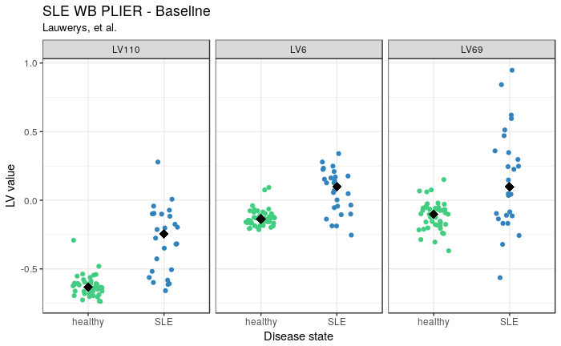

```r
p <- baseline.df %>%
  ggplot2::ggplot(ggplot2::aes(x = `Disease state`, y = Value)) +
  ggplot2::geom_jitter(ggplot2::aes(colour = `Disease state`), width = 0.2) +
  ggplot2::stat_summary(fun.y = "median", size = 4, shape = 18,
                        geom = "point", color = "black") +
  ggplot2::facet_grid(~ LV) +
  ggplot2::theme_bw() +
  ggplot2::labs(y = "LV value",
                title = "SLE WB PLIER - Baseline",
                subtitle = "Lauwerys, et al.") +
  ggplot2::scale_color_manual(values = c("seagreen3", "#3182bd")) +
  ggplot2::theme(legend.position = "none")
p
```

```r
# save plot
plot.file <- file.path(plot.dir,
                       "E-GEOD-39088_SLE-WB_PLIER_baseline.pdf")
ggplot2::ggsave(plot.file, plot = p +
                  ggplot2::theme(text = ggplot2::element_text(size = 15)))
```

```r
# which are likely the 9 IFN-negative patients in
low.ifn.sle <- dplyr::filter(baseline.df,
                             `Disease state` == "SLE") %>%
  dplyr::group_by(LV) %>%
  dplyr::top_n((Value * -1), n = 9) %>%
  dplyr::arrange(LV)
low.ifn.sle
```

| Sample | LV | Annotated | Value | Day | Disease state | Treatment | Patient | Group |
| --- | --- | --- | --- | --- | --- | --- | --- | --- |
| GSM955819_DNA11091-067.CEL | LV110 | 110,IRIS_DendriticCell-LPSstimulated | -0.58214960 | baseline | SLE | SLE Patient, IFN-K 240 microgram, 4 injections, baseline | SLE patient 26 | IFN-K |
| GSM955804_DNA10204-307.CEL | LV110 | 110,IRIS_DendriticCell-LPSstimulated | -0.65878087 | baseline | SLE | SLE Patient, IFN-K 120 microgram, 4 injections, baseline | SLE patient 21 | IFN-K |
| GSM955786_DNA10204-285.CEL | LV110 | 110,IRIS_DendriticCell-LPSstimulated | -0.60777607 | baseline | SLE | SLE Patient, IFN-K 60 microgram, 4 injections, baseline | SLE patient 15 | IFN-K |
| GSM955783_DNA10204-281.CEL | LV110 | 110,IRIS_DendriticCell-LPSstimulated | -0.56272343 | baseline | SLE | SLE Patient, IFN-K 60 microgram, 4 injections, baseline | SLE patient 14 | IFN-K |
| GSM955774_DNA10204-333.CEL | LV110 | 110,IRIS_DendriticCell-LPSstimulated | -0.61327375 | baseline | SLE | SLE Patient, IFN-K 60 microgram, 3 injections, baseline | SLE patient 11 | IFN-K |
| GSM955771_DNA10204-337.CEL | LV110 | 110,IRIS_DendriticCell-LPSstimulated | -0.51795511 | baseline | SLE | SLE Patient, IFN-K 30 microgram, 3 injections, baseline | SLE patient 10 | IFN-K |
| GSM955762_DNA10204-341.CEL | LV110 | 110,IRIS_DendriticCell-LPSstimulated | -0.59924733 | baseline | SLE | SLE patient, Placebo, baseline | SLE patient 7 | Placebo |
| GSM955759_DNA10204-309.CEL | LV110 | 110,IRIS_DendriticCell-LPSstimulated | -0.50584168 | baseline | SLE | SLE patient, Placebo, baseline | SLE patient 6 | Placebo |
| GSM955747_DNA10204-290.CEL | LV110 | 110,IRIS_DendriticCell-LPSstimulated | -0.42684296 | baseline | SLE | SLE patient, Placebo, baseline | SLE patient 2 | Placebo |
| GSM955819_DNA11091-067.CEL | LV6 | 6,REACTOME_INTERFERON_ALPHA_BETA_SIGNALING | -0.04300926 | baseline | SLE | SLE Patient, IFN-K 240 microgram, 4 injections, baseline | SLE patient 26 | IFN-K |

[output cut: 17 more lines]

```r
table(low.ifn.sle$Patient)
```

```
 SLE patient 1 SLE patient 10 SLE patient 11 SLE patient 12 SLE patient 14 SLE patient 15  SLE patient 2
             1              3              3              1              2              3              1
SLE patient 21 SLE patient 22 SLE patient 25 SLE patient 26  SLE patient 6  SLE patient 7
             2              2              1              3              3              2
```

We’ll call anything that’s one of the 9 lowest samples (in more than one LV) IFN-negative for this method.

```r
low.ifn.pat <- names(table(low.ifn.sle$Patient))[table(low.ifn.sle$Patient) > 1]
placebo.pat <-
  unique(baseline.df$Patient[which(baseline.df$Group == "Placebo")])
# remove low IFN patients that are on placebo
low.ifn.pat <- setdiff(low.ifn.pat, placebo.pat)
hi.ifn.pat <- setdiff(array.att$Patient, c(low.ifn.pat, placebo.pat))
hi.ifn.pat <- hi.ifn.pat[grep("patient", hi.ifn.pat)]
ifn.b.df <-
  ifn.b.df %>%
    dplyr::mutate(`IFN-level` = rep(NA, nrow(ifn.b.df))) %>%
    dplyr::mutate(`IFN-level` = dplyr::case_when(
      (Patient %in% low.ifn.pat) ~ "IFN-negative",
      (Patient %in% placebo.pat) ~ "Placebo",
      (Patient %in% hi.ifn.pat) ~ "IFN-positive"
    )) %>%
    readr::write_tsv(path = file.path(results.dir,
                                     "E-GEOD-39088_SLE-WB_PLIER_IFN_B.tsv"))
```

```r
rm(list = setdiff(ls(), c("%>%", "mod.summary.df", "array.att",
                          "sle.b.df", "plot.dir", "results.dir")))
```

### Read in SLE B matrix (in recount2 space)

```r
# read in B matrix
rec.b.file <- file.path("results", "07", "SLE-WB_B_matrix_recount2_model.RDS")
recount.b.mat <- as.data.frame(readRDS(rec.b.file))
recount.b.mat <- tibble::rownames_to_column(recount.b.mat, var = "Annotated")
# reshape
recount.b.df <- reshape2::melt(recount.b.mat)
recount.b.df <-
  recount.b.df %>%
    dplyr::mutate(LV = rep(paste0("LV", 1:nrow(recount.b.mat)),
                           ncol(recount.b.mat) - 1))
colnames(recount.b.df) <- c("Annotated", "Sample", "Value", "LV")
recount.b.df <- recount.b.df[, c("Sample", "LV", "Annotated", "Value")]
head(recount.b.df)
```

|  | Sample | LV | Annotated | Value |
| --- | --- | --- | --- | --- |
| 1 | GSM955680_DNA10204-001.CEL | LV1 | 1,REACTOME_MRNA_SPLICING | -0.0339528969 |
| 2 | GSM955680_DNA10204-001.CEL | LV2 | 2,SVM Monocytes | 0.0810350611 |
| 3 | GSM955680_DNA10204-001.CEL | LV3 | 3,REACTOME_TRANSMISSION_ACROSS_CHEMICAL_SYNAPSES | 0.0381581838 |
| 4 | GSM955680_DNA10204-001.CEL | LV4 | 4,REACTOME_NEURONAL_SYSTEM | 0.0327632585 |
| 5 | GSM955680_DNA10204-001.CEL | LV5 | LV 5 | 0.0002871415 |
| 6 | GSM955680_DNA10204-001.CEL | LV6 | LV 6 | 0.0380337441 |

```r
ifn.b.df <- recount.b.df %>%
              dplyr::filter(LV %in% c("LV116", "LV140")) %>%
              dplyr::right_join(y = array.att, by = c("Sample" = "Source Name"))
```

```
Column `Sample`/`Source Name` joining factor and character vector, coercing into character vector
```

```r
baseline.df <-
  dplyr::bind_rows(dplyr::filter(ifn.b.df, Day == "baseline"),
                   dplyr::filter(ifn.b.df,
                                 `Disease state` == "healthy" & !(grepl("unstimulated",
                                                                        Treatment))))
```

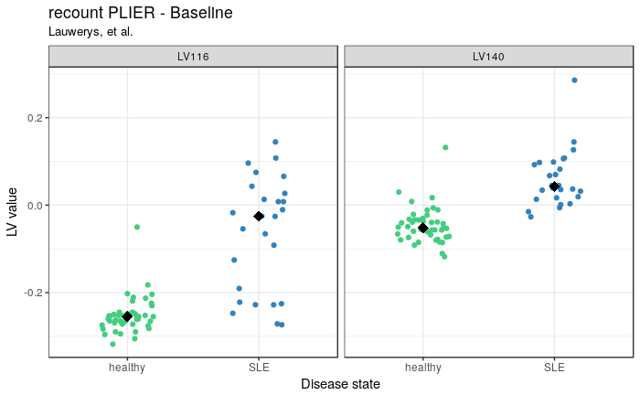

```r
p <- baseline.df %>%
  ggplot2::ggplot(ggplot2::aes(x = `Disease state`, y = Value)) +
  ggplot2::geom_jitter(ggplot2::aes(colour = `Disease state`), width = 0.2) +
  ggplot2::stat_summary(fun.y = "median", size = 4, shape = 18,
                        geom = "point", color = "black") +
  ggplot2::facet_grid(~ LV) +
  ggplot2::theme_bw() +
  ggplot2::labs(y = "LV value",
                title = "recount PLIER - Baseline",
                subtitle = "Lauwerys, et al.") +
  ggplot2::scale_color_manual(values = c("seagreen3", "#3182bd")) +
  ggplot2::theme(legend.position = "none")
p
```

```r
# save plot
plot.file <- file.path(plot.dir,
                       "E-GEOD-39088_recount2_PLIER_baseline.pdf")
ggplot2::ggsave(plot.file, plot = p +
                  ggplot2::theme(text = ggplot2::element_text(size = 15)))
```

We’ll call the 9 patients with the lowest `LV116` values at baseline IFN-negative in this method.

```r
# which are likely the 9 IFN-negative patients in
low.ifn.sle <- dplyr::filter(baseline.df,
                             `Disease state` == "SLE",
                             LV == "LV116") %>%
  dplyr::group_by(LV) %>%
  dplyr::top_n((Value * -1), n = 9)
low.ifn.pat <- low.ifn.sle$Patient
placebo.pat <-
  unique(baseline.df$Patient[which(baseline.df$Group == "Placebo")])
# remove low IFN patients that are on placebo
low.ifn.pat <- setdiff(low.ifn.pat, placebo.pat)
hi.ifn.pat <- setdiff(array.att$Patient, c(low.ifn.pat, placebo.pat))
hi.ifn.pat <- hi.ifn.pat[grep("patient", hi.ifn.pat)]
```

```r
ifn.b.df <-
  ifn.b.df %>%
    dplyr::mutate(`IFN-level` = rep(NA, nrow(ifn.b.df))) %>%
    dplyr::mutate(`IFN-level` = dplyr::case_when(
      (Patient %in% low.ifn.pat) ~ "IFN-negative",
      (Patient %in% placebo.pat) ~ "Placebo",
      (Patient %in% hi.ifn.pat) ~ "IFN-positive"
    )) %>%
  readr::write_tsv(path = file.path(results.dir,
                                    "E-GEOD-39088_recount2_PLIER_IFN_B.tsv"))
```

```r
rm(list = setdiff(ls(), c("%>%", "mod.summary.df", "recount.b.df",
                          "sle.b.df", "plot.dir", "results.dir")))
```

## AMG 811

**E-GEOD-78193; Welcher, et al. 2015.**

I’ll summarize some of the relevant points from Welcher, et al.:

- AMG 811 is a monoclonal antibody against IFN-gamma (type II IFN).
- Patients with SLE received either AMG 811 (different doses and/or adminstration methods) or placebo.
- Whole blood was collected from patients with SLE at day 1 (baseline), day 15, day 56, and at the end of the study (EOS).
- Whole blood was also collected from healthy controls and either stimulated with IFN-gamma for (0, 24, or 48 hrs) or were untreated. The authors identified genes that were differentially expressed between unstimulated and IFN-gamma stimulated samples (IFN-gamma signature). IFN-gamma scores calculated using these genes were similar to other (previously published) IFN gene sets.
- Post-treatment (AMG811) samples showed a significant decrease in a number of the IFN-gamma signature genes

#### Sample-data relationship file

```r
e.78193.sdrf <- data.table::fread(file.path("data",
                                            "sample_info",
                                            "E-GEOD-78193.sdrf.txt"),
                                  data.table = FALSE)
array.att <- e.78193.sdrf[, c("Source Name",
                              "Comment [Sample_source_name]",
                              "Characteristics [subject]",
                              "Characteristics [treatment day]",
                              "Comment [Sample_title]")]
array.att <-
  array.att %>%
    dplyr::mutate(Sample = sub(" 1", "", `Source Name`)) %>%
    dplyr::select(-`Source Name`)
colnames(array.att)[1:4] <- c("Disease state", "Subject",
                              "Day", "Treatment")
# remove IFN-gamma stimulated samples, we won't be using them downstream
array.att <-
  array.att %>%
  dplyr::filter(!(grepl("+ IFN-g", Treatment))) %>%
  dplyr::select(-Treatment)  %>%
  dplyr::mutate(`Disease state` =
                  dplyr::recode(`Disease state`,
                                "systemic lupus erythematosus (SLE) patient" = "SLE",
                                "healthy volunteer" = "healthy"))
```

### Modular transcriptional analyses

```r
# join sample information with the summary of the module gene sets
mod.meta.df <- dplyr::right_join(mod.summary.df, array.att,
                                 by = c("Source Name" = "Sample"))
```

```
Column `Source Name`/`Sample` joining factor and character vector, coercing into character vector
```

```r
# write to file
mod.file <- file.path(results.dir,
                      "E-GEOD-78193_Chiche_et_al_module.tsv")
readr::write_tsv(mod.meta.df, path = mod.file)
```

```r
rm(mod.file, mod.meta.df)
```

### PLIER trained on SLE WB compendium

```r
# join sample info with SLE WB PLIER LVs
sle.b.meta.df <- dplyr::right_join(sle.b.df, array.att, by = "Sample") %>%
  dplyr::filter(LV %in% c("LV6", "LV69", "LV110"))
# write to file
sle.b.file <- file.path(results.dir, "E-GEOD-78193_SLE-WB_PLIER_IFN_B.tsv")
readr::write_tsv(sle.b.meta.df, path = sle.b.file)
```

```r
rm(sle.b.meta.df)
```

### PLIER trained on recount2

```r
# join sample info with SLE WB PLIER LVs
rec.b.meta.df <- dplyr::right_join(recount.b.df, array.att, by = "Sample") %>%
  dplyr::filter(LV %in% c("LV116", "LV140"))
```

```
Column `Sample` joining factor and character vector, coercing into character vector
```

```r
# write to file
rec.b.file <- file.path(results.dir, "E-GEOD-78193_recount2_PLIER_IFN_B.tsv")
readr::write_tsv(rec.b.meta.df, path = rec.b.file)
```